# Part I - (Ford GoBike System Data)

## Univariate Exploration

> In this section, investigate distributions of individual variables. If you see unusual points or outliers, take a deeper look to clean things up and prepare yourself to look at relationships between variables.

### 1. Distribution of duration

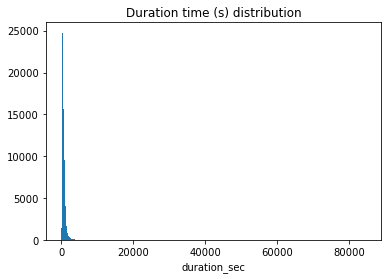

```python
# histogra of duration
bins = np.arange(0, df['duration_sec'].max() + 100, 100)
plt.xlabel('duration_sec')
plt.hist(data = df, x = 'duration_sec', bins = bins )
plt.title('Duration time (s) distribution');
```

- It is clear that above histrigram is heavily right-skwed, so I will transfrom x scale into log
- It is also clear that data has large outliers which shouldn't be included in the figure

```python
np.log10(df['duration_sec'].describe())
```

```
count    5.242728
mean     2.847590
std      3.215515
min      1.785330
25%      2.509203
50%      2.707570
75%      2.897077
max      4.927103
Name: duration_sec, dtype: float64
```

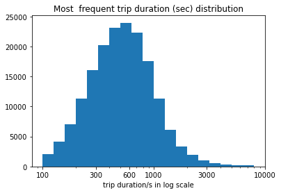

```python
# histogra of duration (log scale)
bins = 10 ** np.arange(2, 4, 0.1)
plt.hist(data = df, x = 'duration_sec', bins = bins)
ticks = [100,300,600,1000,3000,10000]
labels = ['{}'.format(v) for v in ticks]
plt.xscale('log')
plt.xticks(ticks, labels)
plt.xlabel('trip duration/s in log scale')
plt.title('Most  frequent trip duration (sec) distribution');
```

### 2. Distribution of trip start time

```python
# Extract specific trip time (month, day, hour) from "start_time"
# https://www.journaldev.com/23365/python-string-to-datetime-strptime
df['month'] = df['start_time'].dt.month_name()
df['day'] = df['start_time'].dt.day_name()
df['hour'] = df['start_time'].dt.hour
df.head(5)
```

|  | duration_sec | start_time | end_time | start_station_id | start_station_name | start_station_latitude | start_station_longitude | end_station_id | end_station_name | end_station_latitude | ... | bike_id | user_type | member_birth_year | member_gender | bike_share_for_all_trip | duration_min | duration_hr | month | day | hour |
| --- | --- | --- | --- | --- | --- | --- | --- | --- | --- | --- | --- | --- | --- | --- | --- | --- | --- | --- | --- | --- | --- |
| 0 | 52185 | 2019-02-28 17:32:10.145 | 2019-03-01 08:01:55.975 | 21 | Montgomery St BART Station (Market St at 2nd St) | 37.789625 | -122.400811 | 13.0 | Commercial St at Montgomery St | 37.794231 | ... | 4902 | Customer | 1984 | Male | No | 869.750000 | 14.495833 | February | Thursday | 17 |
| 2 | 61854 | 2019-02-28 12:13:13.218 | 2019-03-01 05:24:08.146 | 86 | Market St at Dolores St | 37.769305 | -122.426826 | 3.0 | Powell St BART Station (Market St at 4th St) | 37.786375 | ... | 5905 | Customer | 1972 | Male | No | 1030.900000 | 17.181667 | February | Thursday | 12 |
| 3 | 36490 | 2019-02-28 17:54:26.010 | 2019-03-01 04:02:36.842 | 375 | Grove St at Masonic Ave | 37.774836 | -122.446546 | 70.0 | Central Ave at Fell St | 37.773311 | ... | 6638 | Subscriber | 1989 | Other | No | 608.166667 | 10.136111 | February | Thursday | 17 |
| 4 | 1585 | 2019-02-28 23:54:18.549 | 2019-03-01 00:20:44.074 | 7 | Frank H Ogawa Plaza | 37.804562 | -122.271738 | 222.0 | 10th Ave at E 15th St | 37.792714 | ... | 4898 | Subscriber | 1974 | Male | Yes | 26.416667 | 0.440278 | February | Thursday | 23 |
| 5 | 1793 | 2019-02-28 23:49:58.632 | 2019-03-01 00:19:51.760 | 93 | 4th St at Mission Bay Blvd S | 37.770407 | -122.391198 | 323.0 | Broadway at Kearny | 37.798014 | ... | 5200 | Subscriber | 1959 | Male | No | 29.883333 | 0.498056 | February | Thursday | 23 |

5 rows × 21 columns

#### 2.1 Distribution of daily usage counts

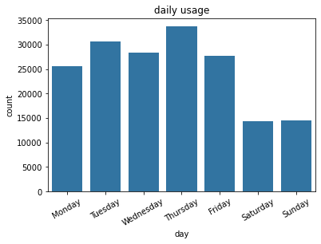

```python
base_color = sb.color_palette()[0]
order = ["Monday","Tuesday","Wednesday","Thursday","Friday","Saturday","Sunday"]
sb.countplot(data = df, x = 'day', color = base_color, order = order)
plt.title('daily usage')
plt.xticks(rotation = 30);
```

- Compared with weekends, weekday has higher bike usage

#### 2.2 Distribution of hourlt usage counts

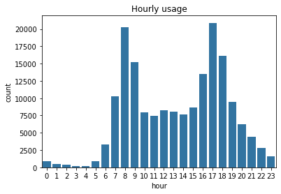

```python
order = np.arange(0,24)
sb.countplot(data = df, x = 'hour', color = base_color, order =order)
plt.title('Hourly usage');
```

- As expected, both morning traffic time (8 am) and afternoon traffic time (5 pm) have the highest bike usage

### 3. Age distribution

```python
df['age'] = 2019 - df['member_birth_year']
```

```python
df['age'].describe()
```

```
count    174875.000000
mean         34.160274
std           9.968641
min          18.000000
25%          27.000000
50%          32.000000
75%          39.000000
max          89.000000
Name: age, dtype: float64
```

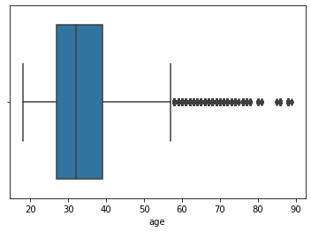

```python
# boxplot
sb.boxplot(data = df, x = 'age');
```

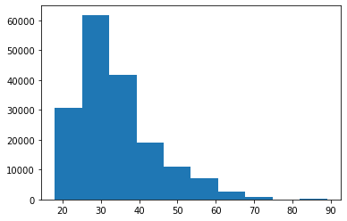

```python
# histogram
plt.hist(data = df, x = 'age');
```

```python
np.log10(df['age'].describe())
```

```
count    5.242728
mean     1.533521
std      0.998636
min      1.255273
25%      1.431364
50%      1.505150
75%      1.591065
max      1.949390
Name: age, dtype: float64
```

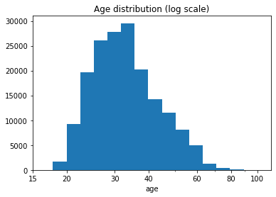

```python
# histogram of log_scale
bins = 10 ** np.arange(1, 2 + 0.05, 0.05)
plt.hist(data = df, x = 'age', bins = bins)
ticks = [15,20, 30, 40, 60,80, 100]
labels = ['{}'.format(v) for v in ticks]
plt.xscale('log')
plt.xticks(ticks, labels)
plt.xlim(15)
plt.xlabel('age')
plt.title('Age distribution (log scale)');
```

- Most age is between 25 - 40 years.

### 4. User type visualization

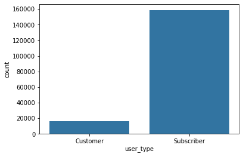

```python
# count user in each category
sb.countplot(data = df, x = 'user_type', color = base_color);
```

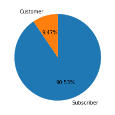

```python
# count proporation in each category
sorted_counts = df['user_type'].value_counts()
plt.pie(sorted_counts, labels = sorted_counts.index, startangle = 90, counterclock = False, autopct='%1.2f%%');
```

- More than 90% of users are members.

### Discuss the distribution(s) of your variable(s) of interest. Were there any unusual points? Did you need to perform any transformations?

> As expected, in "**daily usage**", more bikes are used in weekdays. While for the "**Hourly usage**", 8 am and 5 pm have relatively high usage.

> For "**age**" distribution, there are lots of outliers bigger than 60 years old. But after log transformation, it is more easily to identify most ages are around 25 - 40 years old.

> For "**user type**", more than 90% users are subscribers.

### Of the features you investigated, were there any unusual distributions? Did you perform any operations on the data to tidy, adjust, or change the form of the data? If so, why did you do this?

> Most of the variables need some operations to make them suitable for the next-stage analysis. Such as log transformation, or extracting "month", "day" and "hour" information from "start-time" variable.

## Bivariate Exploration

> In this section, investigate relationships between pairs of variables in your data. Make sure the variables that you cover here have been introduced in some fashion in the previous section (univariate exploration).

### 1. Relationship between customer type and trip durations

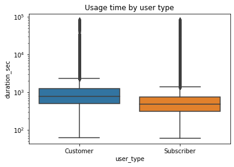

```python
sb.boxplot(data= df, x = 'user_type', y ='duration_sec')
plt.yscale('log')
plt.title('Usage time by user type');
```

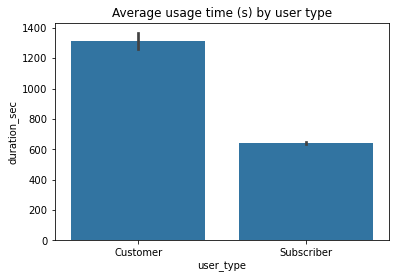

```python
# calculate average usage time per user type
sb.barplot(data =df, x = 'user_type', y ='duration_sec', color = base_color )
plt.title('Average usage time (s) by user type');
```

- The average usage time is higher in customer than subscriber, almost two times. It it a little bit weird, but as the average value can be affected by outliers, I need to take a closer look at the distribution.

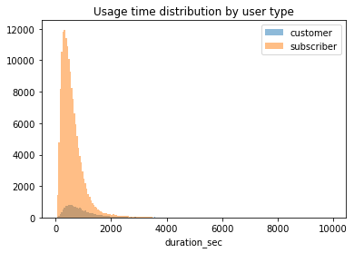

```python
customer = df.query('user_type == "Customer"')
subscriber = df.query('user_type == "Subscriber"')
bins = np.arange(0, 10000, 50)
plt.hist(customer['duration_sec'], alpha = 0.5, bins= bins)
plt.hist(subscriber['duration_sec'], alpha = 0.5, bins = bins)
plt.xlabel('duration_sec')
plt.title('Usage time distribution by user type')
plt.legend(labels = ['customer', 'subscriber']);
```

- From above histogram, we know the distribution in customer is more spread than the subscriber, so the average time usage can be higher in customer group given lots of outliers.

### 2. Relationship between user age and trip durations

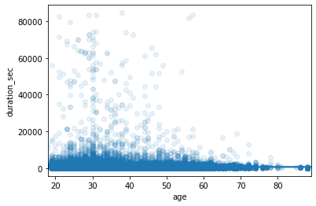

```python
sb.regplot(data = df, x = 'age', y = 'duration_sec',scatter_kws={'alpha':0.1});
```

### 3. Bike daily usage versus customer types

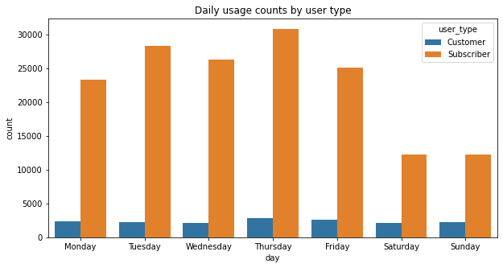

```python
order = ["Monday","Tuesday","Wednesday","Thursday","Friday","Saturday","Sunday"]
plt.figure(figsize = (10,5))
sb.countplot(data = df, x = 'day', hue ='user_type', order = order)
plt.title('Daily usage counts by user type');
```

### 4. Bike hourly usage versus customer types

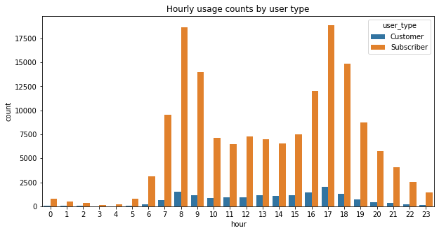

```python
plt.figure(figsize = (10,5))
order = np.arange(0,24)
sb.countplot(data = df, x = 'hour', hue ='user_type', order =order)
plt.title('Hourly usage counts by user type');
```

- Hourly usage tendency is also the same in both customer and subscriber group.

### 4. Top 10 start stations by user groups

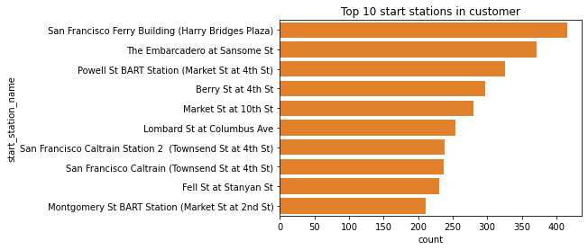

```python
# cusomer group
cus_station = customer['start_station_name'].value_counts()[0:10]
color1 = sb.color_palette()[1]
sb.countplot(data = customer, y = 'start_station_name',order = cus_station.index, color = color1)
plt.title('Top 10 start stations in customer');
```

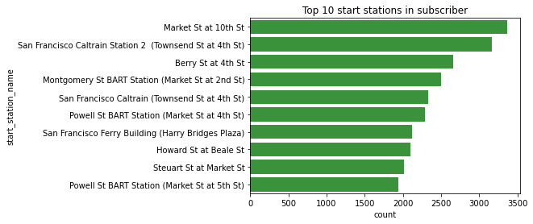

```python
# subscriber group
sub_station = subscriber['start_station_name'].value_counts()[0:10]
color2 = sb.color_palette()[2]
sb.countplot(data = subscriber, y = 'start_station_name',order = sub_station.index, color = color2)
plt.title('Top 10 start stations in subscriber');
```

### Talk about some of the relationships you observed in this part of the investigation. How did the feature(s) of interest vary with other features in the dataset?

> In average, customer has higher usage time compared with subscriber. But the usage time distribution of the customer is more spread which may explain why its average time is higher.

> Users age between 25 - 40 have higher usage times.

### Did you observe any interesting relationships between the other features (not the main feature(s) of interest)?

> Top 10 start stations are not same in "customer" and "subscriber" groups.

## Multivariate Exploration

> Create plots of three or more variables to investigate your data even further. Make sure that your investigations are justified, and follow from your work in the previous sections.

### 1. Daily usage counts versus hourly usage counts by user types

```python
# subscriber
df_sub = subscriber.groupby(['hour','day'], as_index=False).size().reset_index()
index = ["Monday","Tuesday","Wednesday","Thursday","Friday","Saturday","Sunday"]
sub_counts = df_sub.pivot(index = 'day', columns = 'hour', values = 'size')
sub_counts = sub_counts.reindex(index = index)
sub_counts
```

| hour day | 0 | 1 | 2 | 3 | 4 | 5 | 6 | 7 | 8 | 9 | ... | 14 | 15 | 16 | 17 | 18 | 19 | 20 | 21 | 22 | 23 |
| --- | --- | --- | --- | --- | --- | --- | --- | --- | --- | --- | --- | --- | --- | --- | --- | --- | --- | --- | --- | --- | --- |
| Monday | 86 | 43 | 39 | 20 | 37 | 124 | 554 | 1545 | 2963 | 2056 | ... | 782 | 1043 | 1777 | 2992 | 2188 | 1331 | 861 | 561 | 346 | 172 |
| Tuesday | 77 | 51 | 31 | 17 | 30 | 169 | 656 | 2061 | 3924 | 3039 | ... | 965 | 1068 | 2018 | 3653 | 2914 | 1542 | 1043 | 622 | 325 | 164 |
| Wednesday | 75 | 43 | 29 | 14 | 25 | 152 | 530 | 1707 | 3325 | 2411 | ... | 857 | 980 | 1955 | 3498 | 2832 | 1679 | 1069 | 815 | 473 | 214 |
| Thursday | 109 | 41 | 26 | 19 | 40 | 165 | 661 | 2118 | 4166 | 2567 | ... | 1008 | 1241 | 2355 | 4063 | 3297 | 1797 | 1282 | 819 | 489 | 277 |
| Friday | 130 | 77 | 55 | 28 | 40 | 138 | 578 | 1818 | 3576 | 2724 | ... | 786 | 1089 | 1858 | 2765 | 2066 | 1106 | 621 | 466 | 430 | 256 |
| Saturday | 187 | 145 | 66 | 22 | 19 | 25 | 88 | 188 | 442 | 698 | ... | 1074 | 980 | 915 | 930 | 710 | 591 | 393 | 362 | 252 | 201 |
| Sunday | 137 | 81 | 72 | 33 | 19 | 26 | 50 | 137 | 289 | 518 | ... | 1100 | 1067 | 1124 | 977 | 824 | 690 | 491 | 415 | 252 | 133 |

7 rows × 24 columns

```python
# customer
df_cus = customer.groupby(['hour','day'], as_index=False).size().reset_index()
index = ["Monday","Tuesday","Wednesday","Thursday","Friday","Saturday","Sunday"]
cus_counts = df_sub.pivot(index = 'day', columns = 'hour', values = 'size')
cus_counts = sub_counts.reindex(index = index)
cus_counts
```

[output not shown]

7 rows × 24 columns

[figure not shown]

```python
plt.figure(figsize = (20,5))

# subplot of subscriber
plt.subplot(1,2,1)
sb.heatmap(sub_counts)
plt.title('Subscriber')

# subplot of customer
plt.subplot(1,2,2)
sb.heatmap(cus_counts)
plt.title('Customer');
```

### 2. Average daily usage time by user types

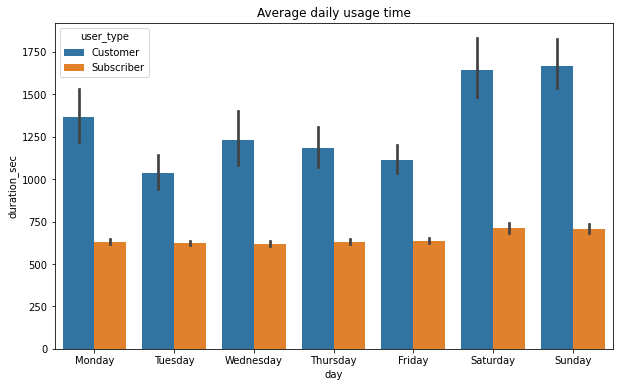

```python
plt.figure(figsize = (10,6))
order = ["Monday","Tuesday","Wednesday","Thursday","Friday","Saturday","Sunday"]
sb.barplot(data = df, x = 'day', y = 'duration_sec', hue = 'user_type', order = order)
plt.title('Average daily usage time');
```

### 3. Average hourly usage time by user types

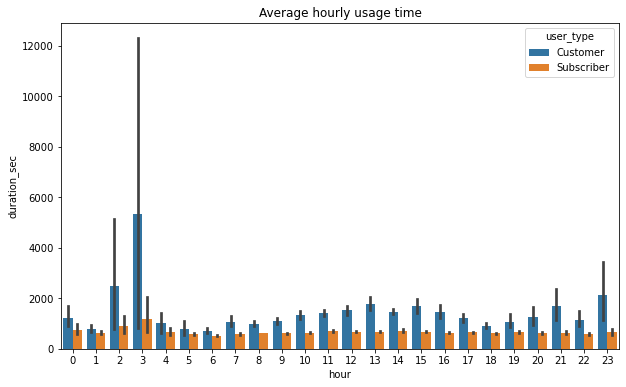

```python
plt.figure(figsize = (10,6))
order = np.arange(0,24)
sb.barplot(data = df, x = 'hour', y = 'duration_sec', hue = 'user_type', order = order)
plt.title('Average hourly usage time');
```

### Talk about some of the relationships you observed in this part of the investigation. Were there features that strengthened each other in terms of looking at your feature(s) of interest?

> But surprisingly, in average, "customer" type has higher usage time.

> Both in "customer" and "subsriber" group, the average usage time is higher in weekends.

### Were there any interesting or surprising interactions between features?

> 3 am has the highest average usage time in both two groups.

```python
df.to_pickle('file.pkl')
```